# Untitled-Copy1

```python
!pip install kaggle
```

```
  Using cached kaggle-1.5.13-py3-none-any.whl
```

```python
import json
!pip install unzip
kaggle_username = "madoukanish"
kaggle_key = "5590594d398d468f363b897eb9afe882"

# Save API token the kaggle.json file
with open("C:/Users/Dell/Downloads/ikeshare/kaggle.json", "w") as f:
   f.write(json.dumps({"username": kaggle_username, "key": kaggle_key}))
```

```python
import pandas as pd
from autogluon.tabular import TabularPredictor
import matplotlib.pyplot as plt
```

```python
# Download the dataset, it will be in a .zip file so you'll need to unzip it as well.
!kaggle competitions download -c bike-sharing-demand
# If you already downloaded it you can use the -o command to overwrite the file
import zipfile
path_to_zip_file="C:/Users/Dell/Downloads/ikeshare/bike-sharing-demand.zip"
with zipfile.ZipFile(path_to_zip_file, 'r') as zip_ref:
    zip_ref.extractall("C:/Users/Dell/Downloads/ikeshare")
```

```python
train = pd.read_csv("train.csv",parse_dates=["datetime"])
train.head()
```

|  | datetime | season | holiday | workingday | weather | temp | atemp | humidity | windspeed | casual | registered | count |
| --- | --- | --- | --- | --- | --- | --- | --- | --- | --- | --- | --- | --- |
| 0 | 2011-01-01 00:00:00 | 1 | 0 | 0 | 1 | 9.84 | 14.395 | 81 | 0.0 | 3 | 13 | 16 |
| 1 | 2011-01-01 01:00:00 | 1 | 0 | 0 | 1 | 9.02 | 13.635 | 80 | 0.0 | 8 | 32 | 40 |
| 2 | 2011-01-01 02:00:00 | 1 | 0 | 0 | 1 | 9.02 | 13.635 | 80 | 0.0 | 5 | 27 | 32 |
| 3 | 2011-01-01 03:00:00 | 1 | 0 | 0 | 1 | 9.84 | 14.395 | 75 | 0.0 | 3 | 10 | 13 |
| 4 | 2011-01-01 04:00:00 | 1 | 0 | 0 | 1 | 9.84 | 14.395 | 75 | 0.0 | 0 | 1 | 1 |

```python
train.describe()
```

|  | season | holiday | workingday | weather | temp | atemp | humidity | windspeed | casual | registered | count |
| --- | --- | --- | --- | --- | --- | --- | --- | --- | --- | --- | --- |
| count | 10886.000000 | 10886.000000 | 10886.000000 | 10886.000000 | 10886.00000 | 10886.000000 | 10886.000000 | 10886.000000 | 10886.000000 | 10886.000000 | 10886.000000 |
| mean | 2.506614 | 0.028569 | 0.680875 | 1.418427 | 20.23086 | 23.655084 | 61.886460 | 12.799395 | 36.021955 | 155.552177 | 191.574132 |
| std | 1.116174 | 0.166599 | 0.466159 | 0.633839 | 7.79159 | 8.474601 | 19.245033 | 8.164537 | 49.960477 | 151.039033 | 181.144454 |
| min | 1.000000 | 0.000000 | 0.000000 | 1.000000 | 0.82000 | 0.760000 | 0.000000 | 0.000000 | 0.000000 | 0.000000 | 1.000000 |
| 25% | 2.000000 | 0.000000 | 0.000000 | 1.000000 | 13.94000 | 16.665000 | 47.000000 | 7.001500 | 4.000000 | 36.000000 | 42.000000 |
| 50% | 3.000000 | 0.000000 | 1.000000 | 1.000000 | 20.50000 | 24.240000 | 62.000000 | 12.998000 | 17.000000 | 118.000000 | 145.000000 |
| 75% | 4.000000 | 0.000000 | 1.000000 | 2.000000 | 26.24000 | 31.060000 | 77.000000 | 16.997900 | 49.000000 | 222.000000 | 284.000000 |
| max | 4.000000 | 1.000000 | 1.000000 | 4.000000 | 41.00000 | 45.455000 | 100.000000 | 56.996900 | 367.000000 | 886.000000 | 977.000000 |

```python
test = pd.read_csv("test.csv",parse_dates=["datetime"])
test.head()
```

|  | datetime | season | holiday | workingday | weather | temp | atemp | humidity | windspeed |
| --- | --- | --- | --- | --- | --- | --- | --- | --- | --- |
| 0 | 2011-01-20 00:00:00 | 1 | 0 | 1 | 1 | 10.66 | 11.365 | 56 | 26.0027 |
| 1 | 2011-01-20 01:00:00 | 1 | 0 | 1 | 1 | 10.66 | 13.635 | 56 | 0.0000 |
| 2 | 2011-01-20 02:00:00 | 1 | 0 | 1 | 1 | 10.66 | 13.635 | 56 | 0.0000 |
| 3 | 2011-01-20 03:00:00 | 1 | 0 | 1 | 1 | 10.66 | 12.880 | 56 | 11.0014 |
| 4 | 2011-01-20 04:00:00 | 1 | 0 | 1 | 1 | 10.66 | 12.880 | 56 | 11.0014 |

```python
test.describe()
```

|  | season | holiday | workingday | weather | temp | atemp | humidity | windspeed |
| --- | --- | --- | --- | --- | --- | --- | --- | --- |
| count | 6493.000000 | 6493.000000 | 6493.000000 | 6493.000000 | 6493.000000 | 6493.000000 | 6493.000000 | 6493.000000 |
| mean | 2.493300 | 0.029108 | 0.685815 | 1.436778 | 20.620607 | 24.012865 | 64.125212 | 12.631157 |
| std | 1.091258 | 0.168123 | 0.464226 | 0.648390 | 8.059583 | 8.782741 | 19.293391 | 8.250151 |
| min | 1.000000 | 0.000000 | 0.000000 | 1.000000 | 0.820000 | 0.000000 | 16.000000 | 0.000000 |
| 25% | 2.000000 | 0.000000 | 0.000000 | 1.000000 | 13.940000 | 16.665000 | 49.000000 | 7.001500 |
| 50% | 3.000000 | 0.000000 | 1.000000 | 1.000000 | 21.320000 | 25.000000 | 65.000000 | 11.001400 |
| 75% | 3.000000 | 0.000000 | 1.000000 | 2.000000 | 27.060000 | 31.060000 | 81.000000 | 16.997900 |
| max | 4.000000 | 1.000000 | 1.000000 | 4.000000 | 40.180000 | 50.000000 | 100.000000 | 55.998600 |

```python
submission = pd.read_csv("sampleSubmission.csv",parse_dates=["datetime"])
submission.head()
```

|  | datetime | count |
| --- | --- | --- |
| 0 | 2011-01-20 00:00:00 | 0 |
| 1 | 2011-01-20 01:00:00 | 0 |
| 2 | 2011-01-20 02:00:00 | 0 |
| 3 | 2011-01-20 03:00:00 | 0 |
| 4 | 2011-01-20 04:00:00 | 0 |

## Step 3: Train a model using AutoGluon’s Tabular Prediction

Requirements:

```python
predictor = TabularPredictor(label="count",eval_metric="root_mean_squared_error",
learner_kwargs={"ignored_columns": ["casual", "registered"]}).fit(train_data=train,
time_limit=50,
presets="best_quality")
```

[output not shown]

[output cut: 10 more lines]

[output not shown]

```
[1000]	valid_set's rmse: 35.1395
```

```
	Ran out of time, early stopping on iteration 1979. Best iteration is:
	[1977]	valid_set's rmse: 33.456
	Time limit exceeded... Skipping LightGBMXT_BAG_L1.
Fitting model: LightGBM_BAG_L1 ... Training model for up to 25.74s of the 42.32s of remaining time.
	Fitting 8 child models (S1F1 - S1F8) | Fitting with SequentialLocalFoldFittingStrategy
```

```
[1000]	valid_set's rmse: 33.1713
```

```
	Ran out of time, early stopping on iteration 1222. Best iteration is:
	[1030]	valid_set's rmse: 33.1496
	Time limit exceeded... Skipping LightGBM_BAG_L1.
Fitting model: RandomForestMSE_BAG_L1 ... Training model for up to 22.16s of the 38.74s of remaining time.
	Warning: Reducing model 'n_estimators' from 300 -> 178 due to low memory. Expected memory usage reduced from 25.25% -> 15.0% of available memory...
	-38.4204	 = Validation score   (-root_mean_squared_error)
	11.78s	 = Training   runtime
	0.52s	 = Validation runtime
Fitting model: CatBoost_BAG_L1 ... Training model for up to 7.91s of the 24.49s of remaining time.
	Fitting 8 child models (S1F1 - S1F8) | Fitting with SequentialLocalFoldFittingStrategy
	Time limit exceeded... Skipping CatBoost_BAG_L1.
Completed 1/20 k-fold bagging repeats ...
Fitting model: WeightedEnsemble_L2 ... Training model for up to 49.78s of the 11.22s of remaining time.
	-37.7763	 = Validation score   (-root_mean_squared_error)
	0.34s	 = Training   runtime
	0.0s	 = Validation runtime
Fitting 9 L2 models ...
Fitting model: LightGBMXT_BAG_L2 ... Training model for up to 10.81s of the 10.79s of remaining time.
	Fitting 8 child models (S1F1 - S1F8) | Fitting with SequentialLocalFoldFittingStrategy
	Ran out of time, early stopping on iteration 404. Best iteration is:
	[403]	valid_set's rmse: 35.3016
	Time limit exceeded... Skipping LightGBMXT_BAG_L2.
Fitting model: LightGBM_BAG_L2 ... Training model for up to 9.19s of the 9.18s of remaining time.
	Fitting 8 child models (S1F1 - S1F8) | Fitting with SequentialLocalFoldFittingStrategy
	Ran out of time, early stopping on iteration 170. Best iteration is:
	[140]	valid_set's rmse: 33.1683
	Ran out of time, early stopping on iteration 176. Best iteration is:
	[174]	valid_set's rmse: 34.1353
	Time limit exceeded... Skipping LightGBM_BAG_L2.
Fitting model: RandomForestMSE_BAG_L2 ... Training model for up to 6.85s of the 6.84s of remaining time.
	-34.6114	 = Validation score   (-root_mean_squared_error)
	29.85s	 = Training   runtime
	1.21s	 = Validation runtime
Completed 1/20 k-fold bagging repeats ...
Fitting model: WeightedEnsemble_L3 ... Training model for up to 49.78s of the -30.01s of remaining time.
	-34.6114	 = Validation score   (-root_mean_squared_error)
	0.0s	 = Training   runtime
	0.0s	 = Validation runtime
AutoGluon training complete, total runtime = 80.1s ... Best model: "WeightedEnsemble_L3"
TabularPredictor saved. To load, use: predictor = TabularPredictor.load("AutogluonModels\ag-20230604_213948\")
```

### Review AutoGluon's training run with ranking of models that did the best.

```python
predictor.fit_summary()
```

[output not shown]

[output not shown]

[output cut: 29 more lines]

```
    pred_time_val_marginal  fit_time_marginal  stack_level  can_infer  \
 0                0.000000           0.015611            3       True
 1                0.770847          22.520428            2       True
 2                0.000000           0.290541            2       True
 3                0.031249           0.786508            1       True
 4                0.053384           0.974899            1       True
 5                0.534612          12.469625            1       True

    fit_order
 0          6
 1          5
 2          4
 3          2
 4          1
 5          3  }
```

```python
predictions = predictor.predict(test)
predictions.head()
```

```
0    17.016666
1    40.540001
2    44.803333
3    47.263332
4    50.266666
Name: count, dtype: float32
```

```python
predictions.describe()
```

```
count    6493.000000
mean       99.959190
std        89.672287
min         2.380000
25%        19.366667
50%        63.893333
75%       166.866669
max       361.260010
Name: count, dtype: float64
```

```python
predictions[predictions<0] = 0
```

```python
submission["count"] = predictions
submission.to_csv("submission.csv", index=False)
```

```python
submission.head()
```

|  | datetime | count |
| --- | --- | --- |
| 0 | 2011-01-20 00:00:00 | 17.016666 |
| 1 | 2011-01-20 01:00:00 | 40.540001 |
| 2 | 2011-01-20 02:00:00 | 44.803333 |
| 3 | 2011-01-20 03:00:00 | 47.263332 |
| 4 | 2011-01-20 04:00:00 | 50.266666 |

```python
!kaggle competitions submit -c bike-sharing-demand -f submission.csv -m "first raw submission"
```

```
Successfully submitted to Bike Sharing Demand
```

```
  4%|4         | 8.00k/188k [00:00<00:05, 31.1kB/s]
 51%|#####1    | 96.0k/188k [00:00<00:00, 337kB/s]
```

```python
!kaggle competitions submissions -c bike-sharing-demand
```

```
fileName                     date                 description                        status    publicScore  privateScore
---------------------------  -------------------  ---------------------------------  --------  -----------  ------------
submission.csv               2023-06-04 21:03:06  first raw submission               complete  1.82777      1.82777
submission_new_hpo.csv       2023-06-02 15:11:33  new features with hyperparameters  complete  0.48573      0.48573
submission_new_features.csv  2023-06-02 14:59:44  new features                       complete  0.63573      0.63573
submission.csv               2023-06-02 13:56:53  first raw submission               complete  1.82777      1.82777
submission_new_hpo.csv       2023-06-01 22:04:46                                     complete  1.84672      1.84672
submission_new_hpo.csv       2023-06-01 21:58:21                                     complete  1.86413      1.86413
submission_new_hpo.csv       2023-06-01 21:52:30                                     complete  1.86413      1.86413
submission_new_features.csv  2023-06-01 21:12:19                                     complete  1.86413      1.86413
submission.csv               2023-06-01 20:23:33                                     complete  1.86413      1.86413
```

#### Initial score of Score: 1.82777

## Step 4: Exploratory Data Analysis and Creating an additional feature

- Any additional feature will do, but a great suggestion would be to separate out the datetime into hour, day, or month parts.

```
array([[<AxesSubplot:title={'center':'datetime'}>,
        <AxesSubplot:title={'center':'season'}>,
        <AxesSubplot:title={'center':'holiday'}>],
       [<AxesSubplot:title={'center':'workingday'}>,
        <AxesSubplot:title={'center':'weather'}>,
        <AxesSubplot:title={'center':'temp'}>],
       [<AxesSubplot:title={'center':'atemp'}>,
        <AxesSubplot:title={'center':'humidity'}>,
        <AxesSubplot:title={'center':'windspeed'}>],
       [<AxesSubplot:title={'center':'casual'}>,
        <AxesSubplot:title={'center':'registered'}>,
        <AxesSubplot:title={'center':'count'}>]], dtype=object)
```

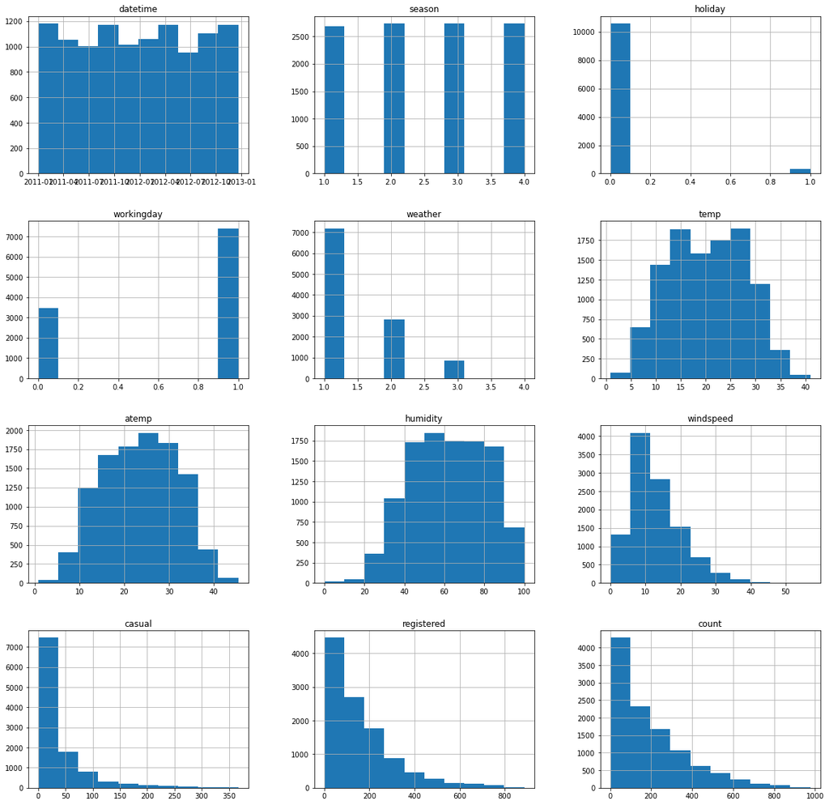

```python
train.hist(figsize=(20,20))
```

```python
train['year'] = train['datetime'].dt.year
train['month'] = train['datetime'].dt.month
train['day'] = train['datetime'].dt.day
train['hour'] = train['datetime'].dt.hour


test['year'] = test['datetime'].dt.year
test['month'] = test['datetime'].dt.month
test['day'] = test['datetime'].dt.day
test['hour'] = test['datetime'].dt.hour
```

## Make category types for these so models know they are not just numbers

- AutoGluon originally sees these as ints, but in reality they are int representations of a category.
- Setting the dtype to category will classify these as categories in AutoGluon.

```python
train["season"] = train["season"].astype("category")
train["weather"] = train["weather"].astype("category")
test["season"] = test["season"].astype("category")
test["weather"] = test["weather"].astype("category")
```

```python
train.head()
```

|  | datetime | season | holiday | workingday | weather | temp | atemp | humidity | windspeed | casual | registered | count | year | month | day | hour |
| --- | --- | --- | --- | --- | --- | --- | --- | --- | --- | --- | --- | --- | --- | --- | --- | --- |
| 0 | 2011-01-01 00:00:00 | 1 | 0 | 0 | 1 | 9.84 | 14.395 | 81 | 0.0 | 3 | 13 | 16 | 2011 | 1 | 1 | 0 |
| 1 | 2011-01-01 01:00:00 | 1 | 0 | 0 | 1 | 9.02 | 13.635 | 80 | 0.0 | 8 | 32 | 40 | 2011 | 1 | 1 | 1 |
| 2 | 2011-01-01 02:00:00 | 1 | 0 | 0 | 1 | 9.02 | 13.635 | 80 | 0.0 | 5 | 27 | 32 | 2011 | 1 | 1 | 2 |
| 3 | 2011-01-01 03:00:00 | 1 | 0 | 0 | 1 | 9.84 | 14.395 | 75 | 0.0 | 3 | 10 | 13 | 2011 | 1 | 1 | 3 |
| 4 | 2011-01-01 04:00:00 | 1 | 0 | 0 | 1 | 9.84 | 14.395 | 75 | 0.0 | 0 | 1 | 1 | 2011 | 1 | 1 | 4 |

```python
test.head()
```

|  | datetime | season | holiday | workingday | weather | temp | atemp | humidity | windspeed | year | month | day | hour |
| --- | --- | --- | --- | --- | --- | --- | --- | --- | --- | --- | --- | --- | --- |
| 0 | 2011-01-20 00:00:00 | 1 | 0 | 1 | 1 | 10.66 | 11.365 | 56 | 26.0027 | 2011 | 1 | 20 | 0 |
| 1 | 2011-01-20 01:00:00 | 1 | 0 | 1 | 1 | 10.66 | 13.635 | 56 | 0.0000 | 2011 | 1 | 20 | 1 |
| 2 | 2011-01-20 02:00:00 | 1 | 0 | 1 | 1 | 10.66 | 13.635 | 56 | 0.0000 | 2011 | 1 | 20 | 2 |
| 3 | 2011-01-20 03:00:00 | 1 | 0 | 1 | 1 | 10.66 | 12.880 | 56 | 11.0014 | 2011 | 1 | 20 | 3 |
| 4 | 2011-01-20 04:00:00 | 1 | 0 | 1 | 1 | 10.66 | 12.880 | 56 | 11.0014 | 2011 | 1 | 20 | 4 |

```
array([[<AxesSubplot:title={'center':'datetime'}>,
        <AxesSubplot:title={'center':'holiday'}>,
        <AxesSubplot:title={'center':'workingday'}>,
        <AxesSubplot:title={'center':'temp'}>],
       [<AxesSubplot:title={'center':'atemp'}>,
        <AxesSubplot:title={'center':'humidity'}>,
        <AxesSubplot:title={'center':'windspeed'}>,
        <AxesSubplot:title={'center':'casual'}>],
       [<AxesSubplot:title={'center':'registered'}>,
        <AxesSubplot:title={'center':'count'}>,
        <AxesSubplot:title={'center':'year'}>,
        <AxesSubplot:title={'center':'month'}>],
       [<AxesSubplot:title={'center':'day'}>,
        <AxesSubplot:title={'center':'hour'}>, <AxesSubplot:>,
        <AxesSubplot:>]], dtype=object)
```

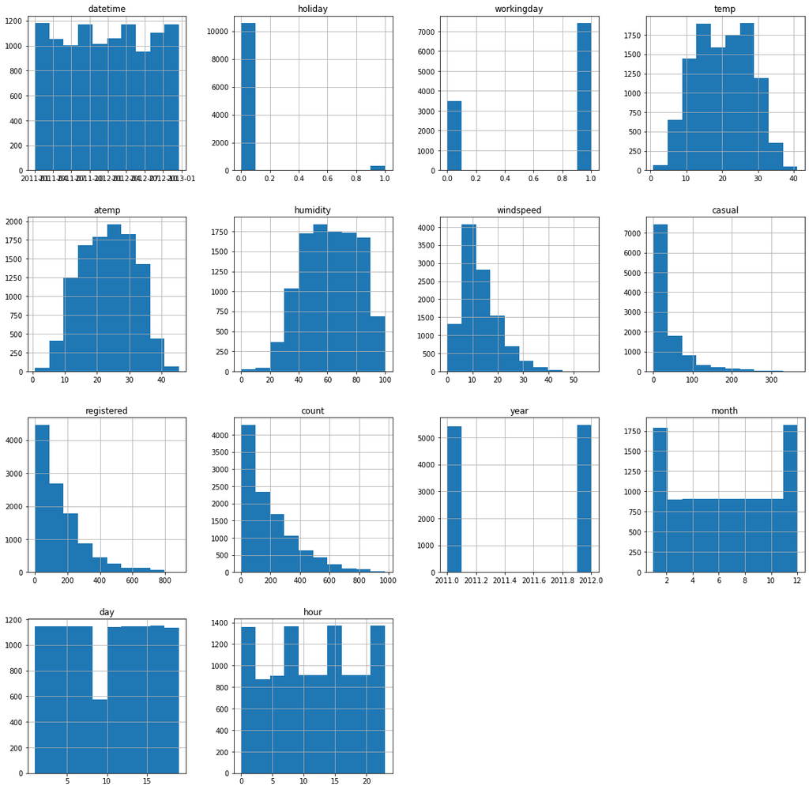

```python
train.hist(figsize=(20,20))
```